# Source memory performance for objects outside the rooms

# 1 Visual inspection of the data

# 2 Novelty Benefits

## 2.1 Check the data

**Is there any corrected hit rate < 0?**

There are 11 negative value out of a total of 80 values.

```
##     SubjectNo    Group MeanCurRt  MeanDur     SFHit       SHit     SrcHit
##  1:       P01 Familiar  3.666667      NaN 0.5000000 0.50000000 0.00000000
##  2:       P03    Novel  5.666667      NaN 0.4444444 0.11111111 0.11111111
##  3:       P11    Novel  4.666667      NaN 0.6111111 0.44444444 0.11111111
##  4:       P66    Novel  6.000000 20.53748 0.5000000 0.22222222 0.05555556
##  5:       P66 Familiar  1.666667 17.79574 0.4444444 0.11111111 0.11111111
##  6:       P71 Familiar  2.000000 25.45671 0.4444444 0.11111111 0.05555556
##  7:       P73 Familiar  2.000000 27.31160 0.4444444 0.05555556 0.00000000
##  8:       P75 Familiar  3.333333 31.98060 0.6666667 0.44444444 0.05555556
##  9:       P76 Familiar  2.333333 26.48253 0.4444444 0.27777778 0.05555556
## 10:       P79 Familiar  1.333333 30.32276 0.4444444 0.22222222 0.05555556
## 11:       P84    Novel  4.666667 23.98126 0.3888889 0.16666667 0.05555556
##        SFFalse     SFalse   SrcFalse       SFAcc        SAcc      SrcAcc
##  1: 0.11111111 0.00000000 0.01851852  0.38888889  0.50000000 -0.01851852
##  2: 0.38888889 0.05555556 0.12962963  0.05555556  0.05555556 -0.01851852
##  3: 0.55555556 0.50000000 0.18518519  0.05555556 -0.05555556 -0.07407407
##  4: 0.50000000 0.05555556 0.14814815  0.00000000  0.16666667 -0.09259259
##  5: 0.50000000 0.05555556 0.14814815 -0.05555556  0.05555556 -0.03703704
##  6: 0.38888889 0.16666667 0.14814815  0.05555556 -0.05555556 -0.09259259
##  7: 0.05555556 0.00000000 0.01851852  0.38888889  0.05555556 -0.01851852
##  8: 0.27777778 0.00000000 0.09259259  0.38888889  0.44444444 -0.03703704
##  9: 0.33333333 0.00000000 0.11111111  0.11111111  0.27777778 -0.05555556
## 10: 0.22222222 0.00000000 0.07407407  0.22222222  0.22222222 -0.01851852
## 11: 0.38888889 0.05555556 0.14814815  0.00000000  0.11111111 -0.09259259
```

## 2.2 Compare mean accuracy between *novel* and *familiar* rooms

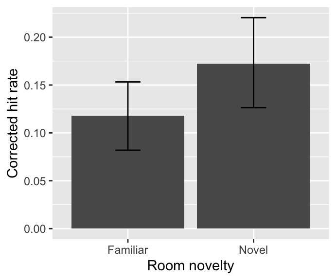

Figure1. Mean accuracy for item memory respectively for Familiar and Novel rooms.

```
##       Group      Mean        SD  N
## 1: Familiar 0.1180556 0.1194031 40
## 2:    Novel 0.1722222 0.1564731 40
```

```
##
##  Paired t-test
##
## data:  SrcAcc by Group
## t = -2.5339, df = 39, p-value = 0.01541
## alternative hypothesis: true difference in means is not equal to 0
## 95 percent confidence interval:
##  -0.09740582 -0.01092751
## sample estimates:
## mean of the differences
##             -0.05416667
```

## 2.3 Any difference between *Early* and *Later* object groups?

### 2.3.1 Check the data

**Is there any corrected hit rate < 0?**

There are 26 negative value out of a total of 160 values.

```
##     SubjectNo    Group ObjOrdGrp MeanCurRt  MeanDur     SFHit      SHit
##  1:       P01 Familiar     Early  3.666667      NaN 0.5555556 0.5555556
##  2:       P01    Novel     Later  6.000000      NaN 0.5555556 0.4444444
##  3:       P01 Familiar     Later  3.666667      NaN 0.4444444 0.4444444
##  4:       P03    Novel     Early  5.666667      NaN 0.3333333 0.1111111
##  5:       P10 Familiar     Later  1.666667      NaN 0.8888889 0.3333333
##  6:       P10    Novel     Later  6.000000      NaN 0.6666667 0.6666667
##  7:       P11    Novel     Early  4.666667      NaN 0.4444444 0.3333333
##  8:       P62    Novel     Early  6.000000 29.09068 0.3333333 0.2222222
##  9:       P62 Familiar     Later  3.000000 25.28234 0.4444444 0.2222222
## 10:       P66    Novel     Early  6.000000 20.53748 0.3333333 0.1111111
## 11:       P66    Novel     Later  6.000000 20.53748 0.6666667 0.3333333
## 12:       P66 Familiar     Early  1.666667 17.79574 0.2222222 0.1111111
## 13:       P71 Familiar     Early  2.000000 25.45671 0.2222222 0.0000000
## 14:       P71 Familiar     Later  2.000000 25.45671 0.6666667 0.2222222
```

[output cut: 69 more lines]

### 2.3.2 Analysis

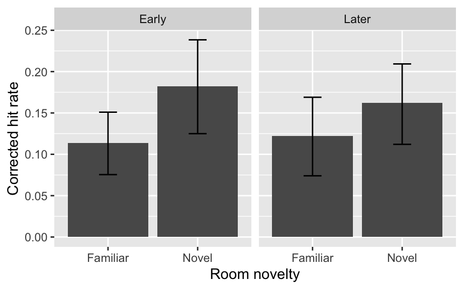

```
##       Group ObjOrdGrp      Mean        SD  N
## 1: Familiar     Early 0.1138889 0.1350156 40
## 2:    Novel     Early 0.1819444 0.1932202 40
## 3:    Novel     Later 0.1625000 0.1656075 40
## 4: Familiar     Later 0.1222222 0.1560004 40
```

```
## $ANOVA
##            Effect DFn DFd          F          p p<.05          ges
## 2           Group   1  39 6.42050005 0.01541037     * 0.0272739771
## 3       ObjOrdGrp   1  39 0.07662083 0.78339192       0.0002948632
## 4 Group:ObjOrdGrp   1  39 0.56195965 0.45797011       0.0018400468
```

# 3 Curiosity Enhancement

## 3.1 Check the data

### 3.1.1 Is there any corrected hit rate < 0?

#### 3.1.1.1 For the data per room

- There are 63 negative values out of a total of 239 values.

```
##     SubjectNo     Context    Group CurRating RoomOrder Duration     SFHit
##  1:       P01     Bedroom Familiar         5     First       NA 0.3333333
##  2:       P01   Classroom Familiar         3    Second       NA 0.3333333
##  3:       P01         Gym Familiar         3    Second       NA 0.8333333
##  4:       P01     Library    Novel         4     First       NA 0.6666667
##  5:       P01 StorageRoom    Novel         7     First       NA 0.3333333
##  6:       P02     Bedroom Familiar         4    Second       NA 0.5000000
##  7:       P03         Gym Familiar         1    Second       NA 0.3333333
##  8:       P03     Library    Novel         7     First       NA 0.3333333
##  9:       P03  LivingRoom    Novel         7    Second       NA 0.1666667
## 10:       P04         Gym Familiar         5    Second       NA 0.6666667
## 11:       P06         Gym Familiar         3    Second       NA 0.6666667
## 12:       P06  LivingRoom    Novel         6     First       NA 0.1666667
## 13:       P08  LivingRoom    Novel         6     First       NA 0.1666667
## 14:       P09  LivingRoom    Novel         5    Second       NA 0.8333333
```

[output cut: 180 more lines]

#### 3.1.1.2 For the data per curiosity group

- There are 11 negative value for curiosity group (1 ~ 3 and 5 ~ 7) out of a total of 78 values.

```
##     SubjectNo CurGrp  MeanDur     SFHit       SHit     SrcHit    SFFalse
##  1:       P01    Low      NaN 0.5833333 0.58333333 0.00000000 0.11111111
##  2:       P03   High      NaN 0.2777778 0.00000000 0.05555556 0.38888889
##  3:       P11   High      NaN 0.3333333 0.22222222 0.11111111 0.55555556
##  4:       P66   High 20.53748 0.5000000 0.22222222 0.05555556 0.50000000
##  5:       P66    Low 17.79574 0.4444444 0.11111111 0.11111111 0.50000000
##  6:       P71    Low 25.45671 0.4444444 0.11111111 0.05555556 0.38888889
##  7:       P73    Low 27.31160 0.4444444 0.05555556 0.00000000 0.05555556
##  8:       P75    Low 31.09535 0.7500000 0.41666667 0.08333333 0.27777778
##  9:       P76    Low 26.80689 0.5000000 0.33333333 0.08333333 0.33333333
## 10:       P79    Low 30.32276 0.4444444 0.22222222 0.05555556 0.22222222
## 11:       P84   High 23.84103 0.4166667 0.08333333 0.08333333 0.38888889
##         SFalse   SrcFalse       SFAcc        SAcc       SrcAcc
##  1: 0.00000000 0.01851852  0.47222222  0.58333333 -0.018518519
##  2: 0.05555556 0.12962963 -0.11111111 -0.05555556 -0.074074074
##  3: 0.50000000 0.18518519 -0.22222222 -0.27777778 -0.074074074
##  4: 0.05555556 0.14814815  0.00000000  0.16666667 -0.092592593
##  5: 0.05555556 0.14814815 -0.05555556  0.05555556 -0.037037037
##  6: 0.16666667 0.14814815  0.05555556 -0.05555556 -0.092592593
##  7: 0.00000000 0.01851852  0.38888889  0.05555556 -0.018518519
##  8: 0.00000000 0.09259259  0.47222222  0.41666667 -0.009259259
##  9: 0.00000000 0.11111111  0.16666667  0.33333333 -0.027777778
## 10: 0.00000000 0.07407407  0.22222222  0.22222222 -0.018518519
## 11: 0.05555556 0.14814815  0.02777778  0.02777778 -0.064814815
```

#### 3.1.1.3 For the data per curiosity group (median)

- There are 11 negative value for curiosity group (median) out of a total of 79 values.

```
##     SubjectNo CurGrpMedian  MeanDur     SFHit       SHit     SrcHit
##  1:       P01          Low      NaN 0.6111111 0.55555556 0.00000000
##  2:       P03         High      NaN 0.2777778 0.00000000 0.05555556
##  3:       P11         High      NaN 0.3333333 0.22222222 0.11111111
##  4:       P66         High 20.53748 0.5000000 0.22222222 0.05555556
##  5:       P66          Low 17.79574 0.4444444 0.11111111 0.11111111
##  6:       P71          Low 25.45671 0.4444444 0.11111111 0.05555556
##  7:       P73          Low 27.31160 0.4444444 0.05555556 0.00000000
##  8:       P75          Low 31.98060 0.6666667 0.44444444 0.05555556
##  9:       P76          Low 26.80689 0.5000000 0.33333333 0.08333333
## 10:       P79          Low 30.32276 0.4444444 0.22222222 0.05555556
## 11:       P84         High 23.98126 0.3888889 0.16666667 0.05555556
##        SFFalse     SFalse   SrcFalse       SFAcc        SAcc      SrcAcc
##  1: 0.11111111 0.00000000 0.01851852  0.50000000  0.55555556 -0.01851852
##  2: 0.38888889 0.05555556 0.12962963 -0.11111111 -0.05555556 -0.07407407
##  3: 0.55555556 0.50000000 0.18518519 -0.22222222 -0.27777778 -0.07407407
##  4: 0.50000000 0.05555556 0.14814815  0.00000000  0.16666667 -0.09259259
##  5: 0.50000000 0.05555556 0.14814815 -0.05555556  0.05555556 -0.03703704
##  6: 0.38888889 0.16666667 0.14814815  0.05555556 -0.05555556 -0.09259259
##  7: 0.05555556 0.00000000 0.01851852  0.38888889  0.05555556 -0.01851852
##  8: 0.27777778 0.00000000 0.09259259  0.38888889  0.44444444 -0.03703704
##  9: 0.33333333 0.00000000 0.11111111  0.16666667  0.33333333 -0.02777778
## 10: 0.22222222 0.00000000 0.07407407  0.22222222  0.22222222 -0.01851852
## 11: 0.38888889 0.05555556 0.14814815  0.00000000  0.11111111 -0.09259259
```

## 3.2 Mean accuracy of item memory as a function of curiosity rating

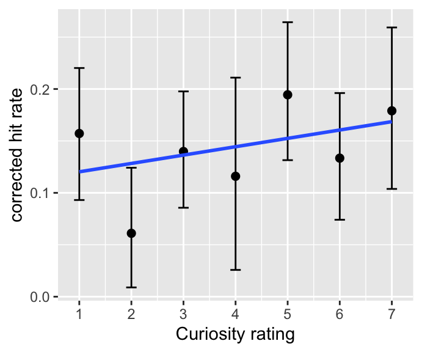

## 3.3 Testing the relationship between mean accuracy of item memory and curiosity rating

Build models with item memory accuracy as $y$ and examine effects of curiosity rating by including it into the model and then comparing the model fits.

- `baseline.rating` is the model with only an intercept, showing no change in item memory as a function of curiosity rating.
- `rating.intercept` is the model with $\small CuriosityRating$ included, showing the effects of curiosity rating.
- `rating.slope` is the model allowing the slope (i.e., relationship between item memory and curiosity rating) varying across participants.

```
##                  Model df       AIC       BIC   logLik   Test   L.Ratio
## baseline.rating      1  3 -79.78936 -69.35997 42.89468
## rating.intercept     2  4 -80.21788 -66.31203 44.10894 1 vs 2 2.4285229
## rating.slope         3  6 -77.20397 -56.34519 44.60199 2 vs 3 0.9860879
##                  p-value
## baseline.rating
## rating.intercept  0.1191
## rating.slope      0.6108
```

```
## Linear mixed-effects model fit by maximum likelihood
##  Data: outside.hit.rate.per.room
##         AIC       BIC   logLik
##   -77.20397 -56.34519 44.60199
##
## Random effects:
##  Formula: ~1 + CurRating | SubjectNo
##  Structure: General positive-definite, Log-Cholesky parametrization
##             StdDev      Corr
## (Intercept) 0.067651817 (Intr)
## CurRating   0.009564513 0.491
## Residual    0.185328650
##
## Fixed effects: SrcAcc ~ CurRating
##                  Value   Std.Error  DF  t-value p-value
## (Intercept) 0.10931873 0.029508327 198 3.704674  0.0003
## CurRating   0.00890049 0.006297506 198 1.413336  0.1591
##  Correlation:
##           (Intr)
## CurRating -0.769
##
## Standardized Within-Group Residuals:
##        Min         Q1        Med         Q3        Max
## -1.8538642 -0.6893741 -0.1519120  0.6032195  3.8035693
##
## Number of Observations: 239
## Number of Groups: 40
```

## 3.4 Check the curiosity groups

### 3.4.1 Separate the groups according to the rating

- *High*: curiosity rating > 4
- *Low*: curiosity rating < 4
- For curiosity rating = 4, discarded

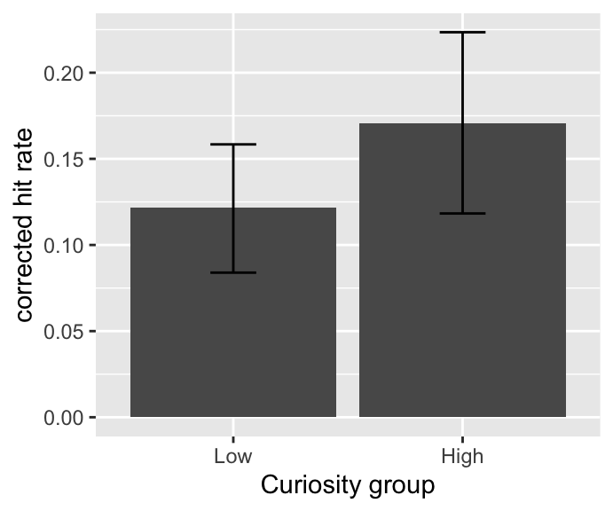

```
##    CurGrp      Mean        SD  N
## 1:    Low 0.1214669 0.1232120 38
## 2:   High 0.1706944 0.1651208 40
```

```
## Linear mixed-effects model fit by maximum likelihood
##  Data: outside.hit.rate.curiosity.group[!is.na(CurGrp)]
##         AIC      BIC   logLik
##   -86.40335 -72.2631 49.20167
##
## Random effects:
##  Formula: ~1 + CurGrp | SubjectNo
##  Structure: General positive-definite, Log-Cholesky parametrization
##             StdDev     Corr
## (Intercept) 0.11054976 (Intr)
## CurGrpHigh  0.11736011 -0.078
## Residual    0.05098935
##
## Fixed effects: SrcAcc ~ CurGrp
##                  Value  Std.Error DF  t-value p-value
## (Intercept) 0.11895127 0.01984703 39 5.993404  0.0000
## CurGrpHigh  0.05174318 0.02237046 37 2.313013  0.0264
##  Correlation:
##            (Intr)
## CurGrpHigh -0.239
##
## Standardized Within-Group Residuals:
##           Min            Q1           Med            Q3           Max
## -1.218462e+00 -3.512682e-01 -2.056505e-05  2.388565e-01  1.200246e+00
##
## Number of Observations: 78
## Number of Groups: 40
```

#### 3.4.1.1 Curiosity groups and temporal order of the objects

##### 3.4.1.1.1 Check the data

**Is there any corrected hit rate < 0?**

```
##     SubjectNo CurGrp ObjOrdGrp     SFHit      SHit     SrcHit    SFFalse
##  1:       P01    Low     Early 0.6666667 0.6666667 0.00000000 0.11111111
##  2:       P01   High     Later 0.4444444 0.4444444 0.00000000 0.11111111
##  3:       P01    Low     Later 0.5000000 0.5000000 0.00000000 0.11111111
##  4:       P02    Low     Later 0.6666667 0.3333333 0.00000000 0.16666667
##  5:       P02   High     Later 0.6666667 0.6666667 0.00000000 0.16666667
##  6:       P03   High     Early 0.3333333 0.0000000 0.11111111 0.38888889
##  7:       P03   High     Later 0.2222222 0.0000000 0.00000000 0.38888889
##  8:       P03    Low     Early 0.3333333 0.1666667 0.00000000 0.38888889
##  9:       P06   High     Early 0.3333333 0.0000000 0.00000000 0.27777778
## 10:       P06    Low     Later 0.6666667 0.3333333 0.00000000 0.27777778
## 11:       P10    Low     Later 0.8888889 0.3333333 0.11111111 0.50000000
## 12:       P10   High     Later 0.6666667 0.6666667 0.11111111 0.50000000
## 13:       P11   High     Later 0.4444444 0.2222222 0.11111111 0.55555556
## 14:       P11   High     Early 0.2222222 0.2222222 0.11111111 0.55555556
```

[output cut: 53 more lines]

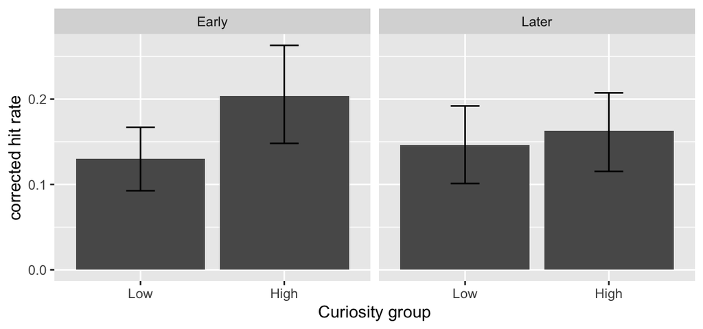

```
##    CurGrp ObjOrdGrp      Mean        SD  N
## 1:    Low     Early 0.1298733 0.1209079 38
## 2:   High     Early 0.2036111 0.1878825 40
## 3:   High     Later 0.1625463 0.1561477 40
## 4:    Low     Later 0.1461988 0.1500775 38
```

```
##           Model df       AIC       BIC   logLik   Test  L.Ratio p-value
## baseline      1  8 -151.9057 -127.5068 83.95284
## ord.model     2  9 -150.1138 -122.6651 84.05690 1 vs 2 0.208111  0.6483
## cur.model     3 10 -152.7333 -122.2348 86.36666 2 vs 3 4.619525  0.0316
## int.model     4 11 -153.3392 -119.7908 87.66961 3 vs 4 2.605899  0.1065
```

```
## Linear mixed-effects model fit by maximum likelihood
##  Data: outside.hit.rate.item.order.curiosity[!is.na(CurGrp)]
##         AIC       BIC   logLik
##   -153.3392 -119.7908 87.66961
##
## Random effects:
##  Formula: ~1 + CurGrp + ObjOrdGrp | SubjectNo
##  Structure: General positive-definite, Log-Cholesky parametrization
##                StdDev     Corr
## (Intercept)    0.07113457 (Intr) CrGrpH
## CurGrpHigh     0.06991569  0.700
## ObjOrdGrpLater 0.03958941  0.112 -0.542
## Residual       0.11060785
##
## Fixed effects: SrcAcc ~ ObjOrdGrp + CurGrp + ObjOrdGrp:CurGrp
##                                 Value  Std.Error  DF   t-value p-value
## (Intercept)                0.12818135 0.02150539 113  5.960428  0.0000
## ObjOrdGrpLater             0.01684992 0.02651488 113  0.635489  0.5264
## CurGrpHigh                 0.07542976 0.02778438 113  2.714826  0.0077
## ObjOrdGrpLater:CurGrpHigh -0.05791474 0.03592530 113 -1.612088  0.1097
##  Correlation:
##                           (Intr) ObjOGL CrGrpH
## ObjOrdGrpLater            -0.564
## CurGrpHigh                -0.407  0.395
## ObjOrdGrpLater:CurGrpHigh  0.427 -0.696 -0.645
##
## Standardized Within-Group Residuals:
##        Min         Q1        Med         Q3        Max
## -1.5037354 -0.6671875 -0.2021246  0.6384351  2.6442464
##
## Number of Observations: 156
## Number of Groups: 40
```

##### 3.4.1.1.2 *Post hoc*

```
##
##   Simultaneous Tests for General Linear Hypotheses
##
## Fit: lme.formula(fixed = SrcAcc ~ ObjOrdGrp + CurGrp + ObjOrdGrp:CurGrp,
##     data = outside.hit.rate.item.order.curiosity[!is.na(CurGrp)],
##     random = ~1 + CurGrp + ObjOrdGrp | SubjectNo, method = "ML",
##     na.action = na.exclude, control = list(msMaxIter = 500, opt = "optim",
##         msVerbose = FALSE))
##
## Linear Hypotheses:
##                          Estimate Std. Error z value Pr(>|z|)
## Early: High vs. Low == 0  0.07543    0.02743   2.750  0.00595 **
## Late:  High vs. Low == 0  0.01752    0.02748   0.637  0.52392
## ---
## Signif. codes:  0 '***' 0.001 '**' 0.01 '*' 0.05 '.' 0.1 ' ' 1
## (Adjusted p values reported -- none method)
```

### 3.4.2 Separate the groups according to the median rating of each participant

- *High*: curiosity rating > median of the participant
- *Low*: curiosity rating < median of the participant

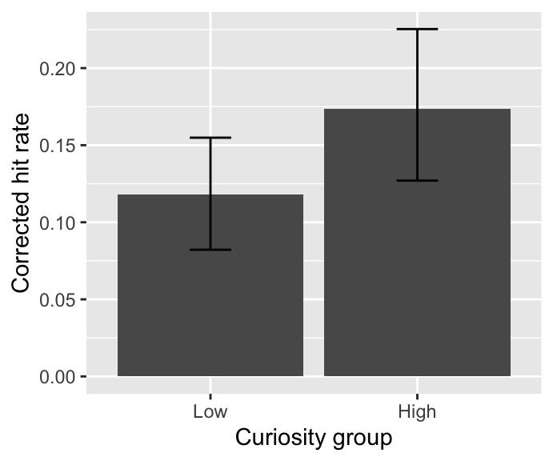

```
## Linear mixed-effects model fit by maximum likelihood
##  Data: outside.hit.rate.curiosity.group.median[!is.na(CurGrpMedian)]
##        AIC       BIC  logLik
##   -87.5526 -73.33591 49.7763
##
## Random effects:
##  Formula: ~1 + CurGrpMedian | SubjectNo
##  Structure: General positive-definite, Log-Cholesky parametrization
##                  StdDev     Corr
## (Intercept)      0.10680190 (Intr)
## CurGrpMedianHigh 0.12555987 -0.137
## Residual         0.05171143
##
## Fixed effects: SrcAcc ~ CurGrpMedian
##                      Value  Std.Error DF  t-value p-value
## (Intercept)      0.1180556 0.01900424 39 6.212063  0.0000
## CurGrpMedianHigh 0.0560965 0.02354738 38 2.382282  0.0223
##  Correlation:
##                  (Intr)
## CurGrpMedianHigh -0.259
##
## Standardized Within-Group Residuals:
##          Min           Q1          Med           Q3          Max
## -1.148166422 -0.282563070  0.005715828  0.256239147  1.180012342
##
## Number of Observations: 79
## Number of Groups: 40
```

#### 3.4.2.1 Curiosity groups and temporal order of the objects

##### 3.4.2.1.1 Check the data

```
##     SubjectNo CurGrpMedian ObjOrdGrp     SFHit      SHit    SrcHit
##  1:       P01          Low     Early 0.6666667 0.6666667 0.0000000
##  2:       P01          Low     Later 0.5555556 0.4444444 0.0000000
##  3:       P01         High     Later 0.4444444 0.4444444 0.0000000
##  4:       P02          Low     Later 0.6666667 0.3333333 0.0000000
##  5:       P02         High     Later 0.6666667 0.6666667 0.0000000
##  6:       P03         High     Early 0.3333333 0.0000000 0.1111111
##  7:       P03         High     Later 0.2222222 0.0000000 0.0000000
##  8:       P06         High     Early 0.3333333 0.0000000 0.0000000
##  9:       P06          Low     Later 0.6666667 0.3333333 0.0000000
## 10:       P07          Low     Early 0.8333333 0.0000000 0.0000000
## 11:       P10          Low     Later 0.8888889 0.3333333 0.1111111
## 12:       P10         High     Later 0.6666667 0.6666667 0.1111111
## 13:       P11         High     Later 0.4444444 0.2222222 0.1111111
## 14:       P11          Low     Early 0.7777778 0.6666667 0.1111111
```

[output cut: 59 more lines]

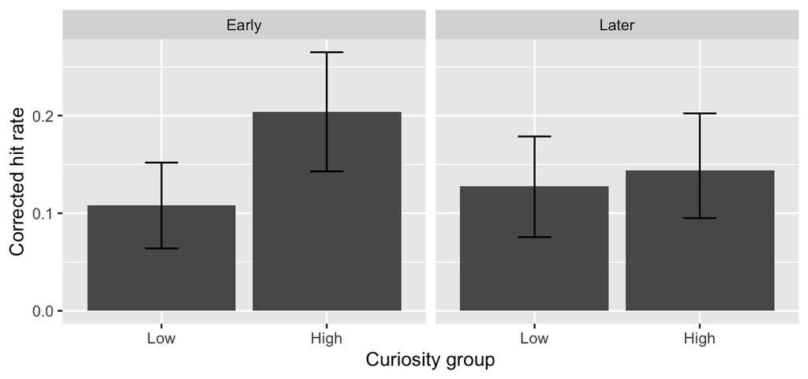

```
##    CurGrpMedian ObjOrdGrp      Mean        SD  N
## 1:          Low     Early 0.1083333 0.1464498 40
## 2:          Low     Later 0.1277778 0.1705416 40
## 3:         High     Early 0.2037037 0.2071741 39
## 4:         High     Later 0.1438746 0.1773418 39
```

```
##           Model df       AIC       BIC   logLik   Test  L.Ratio p-value
## baseline      1  8 -106.7578 -82.25702 61.37889
## ord.model     2  9 -104.7875 -77.22411 61.39373 1 vs 2 0.029688  0.8632
## cur.model     3 10 -107.8327 -77.20670 63.91632 2 vs 3 5.045178  0.0247
## int.model     4 11 -109.3756 -75.68709 65.68782 3 vs 4 3.542993  0.0598
```

```
## Linear mixed-effects model fit by maximum likelihood
##  Data: outside.hit.rate.item.order.curiosity.median[!is.na(CurGrpMedian)]
##         AIC       BIC   logLik
##   -109.3756 -75.68709 65.68782
##
## Random effects:
##  Formula: ~1 + CurGrpMedian + ObjOrdGrp | SubjectNo
##  Structure: General positive-definite, Log-Cholesky parametrization
##                  StdDev     Corr
## (Intercept)      0.09177459 (Intr) CrGrMH
## CurGrpMedianHigh 0.07520889  0.822
## ObjOrdGrpLater   0.09752662 -0.502 -0.667
## Residual         0.12526359
##
## Fixed effects: SrcAcc ~ ObjOrdGrp + CurGrpMedian + ObjOrdGrp:CurGrpMedian
##                                       Value  Std.Error  DF   t-value
## (Intercept)                      0.10833333 0.02486959 115  4.356056
## ObjOrdGrpLater                   0.01944444 0.03238655 115  0.600386
## CurGrpMedianHigh                 0.09284743 0.03116843 115  2.978894
## ObjOrdGrpLater:CurGrpMedianHigh -0.07640105 0.04043872 115 -1.889304
##                                 p-value
## (Intercept)                      0.0000
## ObjOrdGrpLater                   0.5494
## CurGrpMedianHigh                 0.0035
## ObjOrdGrpLater:CurGrpMedianHigh  0.0614
##  Correlation:
##                                 (Intr) ObjOGL CrGrMH
## ObjOrdGrpLater                  -0.643
## CurGrpMedianHigh                -0.331  0.274
## ObjOrdGrpLater:CurGrpMedianHigh  0.400 -0.615 -0.651
##
## Standardized Within-Group Residuals:
##        Min         Q1        Med         Q3        Max
## -2.0069336 -0.5523128 -0.1014983  0.6154627  2.2125304
##
## Number of Observations: 158
## Number of Groups: 40
```

##### 3.4.2.1.2 *Post hoc*

```
##
##   Simultaneous Tests for General Linear Hypotheses
##
## Fit: lme.formula(fixed = SrcAcc ~ ObjOrdGrp + CurGrpMedian + ObjOrdGrp:CurGrpMedian,
##     data = outside.hit.rate.item.order.curiosity.median[!is.na(CurGrpMedian)],
##     random = ~1 + CurGrpMedian + ObjOrdGrp | SubjectNo, method = "ML",
##     na.action = na.exclude, control = list(msMaxIter = 500, opt = "optim",
##         msVerbose = FALSE))
##
## Linear Hypotheses:
##                          Estimate Std. Error z value Pr(>|z|)
## Early: High vs. Low == 0  0.09285    0.03077   3.017  0.00255 **
## Late:  High vs. Low == 0  0.01645    0.03069   0.536  0.59209
## ---
## Signif. codes:  0 '***' 0.001 '**' 0.01 '*' 0.05 '.' 0.1 ' ' 1
## (Adjusted p values reported -- none method)
```

# 4 **Novelty** or **Curiosity**?

## 4.1 For Curiosity group splitted by score (*Low*: 1 ~ 3; *High*: 5 ~ 7)

### 4.1.1 Curiosity first, novelty next

```
##               Model df       AIC       BIC   logLik   Test  L.Ratio
## base.model        1  8 -71.57938 -44.57715 43.78969
## cur.scr.model     2  9 -73.05273 -42.67522 45.52636 1 vs 2 3.473353
## nov.scr.model     3 10 -73.36965 -39.61687 46.68483 2 vs 3 2.316923
##               p-value
## base.model
## cur.scr.model  0.0624
## nov.scr.model  0.1280
```

```
## Linear mixed-effects model fit by maximum likelihood
##  Data: outside.hit.rate.per.room[!is.na(CurGrp)]
##         AIC       BIC   logLik
##   -73.05273 -42.67522 45.52636
##
## Random effects:
##  Formula: ~1 + CurGrp + Group | SubjectNo
##  Structure: General positive-definite, Log-Cholesky parametrization
##             StdDev       Corr
## (Intercept) 0.1240228342 (Intr) CrGrpL
## CurGrpLow   0.0462519401 -0.987
## GroupNovel  0.0001359998 -0.002  0.002
## Residual    0.1778267587
##
## Fixed effects: SrcAcc ~ CurGrp
##                   Value  Std.Error  DF   t-value p-value
## (Intercept)  0.16962321 0.02613983 175  6.489071  0.0000
## CurGrpLow   -0.04849258 0.02588088 175 -1.873683  0.0626
##  Correlation:
##           (Intr)
## CurGrpLow -0.652
##
## Standardized Within-Group Residuals:
##        Min         Q1        Med         Q3        Max
## -2.0128452 -0.7799481 -0.1221727  0.5950935  3.4319460
##
## Number of Observations: 216
## Number of Groups: 40
```

### 4.1.2 Novelty first, curiosity next

```
##               Model df       AIC       BIC   logLik   Test  L.Ratio
## base.model        1  8 -71.57938 -44.57715 43.78969
## nov.scr.model     2  9 -75.38023 -45.00272 46.69011 1 vs 2 5.800851
## cur.scr.model     3 10 -73.36965 -39.61687 46.68483 2 vs 3 0.010574
##               p-value
## base.model
## nov.scr.model  0.0160
## cur.scr.model  0.9181
```

```
## Linear mixed-effects model fit by maximum likelihood
##  Data: outside.hit.rate.per.room[!is.na(CurGrp)]
##         AIC       BIC   logLik
##   -75.38023 -45.00272 46.69011
##
## Random effects:
##  Formula: ~1 + CurGrp + Group | SubjectNo
##  Structure: General positive-definite, Log-Cholesky parametrization
##             StdDev       Corr
## (Intercept) 0.1228670792 (Intr) CrGrpL
## CurGrpLow   0.0449496133 -0.983
## GroupNovel  0.0003279595 -0.001  0.002
## Residual    0.1768613888
##
## Fixed effects: SrcAcc ~ Group
##                  Value  Std.Error  DF  t-value p-value
## (Intercept) 0.11582127 0.02174087 175 5.327351  0.0000
## GroupNovel  0.06082631 0.02505455 175 2.427755  0.0162
##  Correlation:
##            (Intr)
## GroupNovel -0.418
##
## Standardized Within-Group Residuals:
##        Min         Q1        Med         Q3        Max
## -2.0735083 -0.7497338 -0.1341616  0.6067780  3.4289120
##
## Number of Observations: 216
## Number of Groups: 40
```

## 4.2 For Curiosity group splitted by individual medians

### 4.2.1 Curiosity first, novelty next

```
##              Model df       AIC       BIC   logLik   Test  L.Ratio p-value
## base.model       1  8 -62.85655 -35.49227 39.42827
## cur.md.model     2  9 -64.95826 -34.17344 41.47913 1 vs 2 4.101711  0.0428
## nov.md.model     3 10 -62.98303 -28.77768 41.49151 2 vs 3 0.024767  0.8749
```

```
## Linear mixed-effects model fit by maximum likelihood
##  Data: outside.hit.rate.per.room[!is.na(CurGrpMedian)]
##         AIC       BIC   logLik
##   -64.95826 -34.17344 41.47913
##
## Random effects:
##  Formula: ~1 + CurGrpMedian + Group | SubjectNo
##  Structure: General positive-definite, Log-Cholesky parametrization
##                 StdDev      Corr
## (Intercept)     0.124541771 (Intr) CrGrML
## CurGrpMedianLow 0.056424115 -0.991
## GroupNovel      0.000407031 -0.002  0.003
## Residual        0.184763442
##
## Fixed effects: SrcAcc ~ CurGrpMedian
##                       Value  Std.Error  DF   t-value p-value
## (Intercept)      0.17288342 0.02666255 185  6.484129  0.0000
## CurGrpMedianLow -0.05371489 0.02638889 185 -2.035511  0.0432
##  Correlation:
##                 (Intr)
## CurGrpMedianLow -0.699
##
## Standardized Within-Group Residuals:
##        Min         Q1        Med         Q3        Max
## -1.9084232 -0.7512671 -0.1281156  0.6056003  3.4327303
##
## Number of Observations: 226
## Number of Groups: 40
```

### 4.2.2 Novelty first, curiosity next

```
##              Model df       AIC       BIC   logLik   Test  L.Ratio p-value
## base.model       1  8 -62.85655 -35.49227 39.42827
## nov.md.model     2  9 -64.07867 -33.29385 41.03933 1 vs 2 3.222117  0.0726
## cur.md.model     3 10 -62.98303 -28.77768 41.49151 2 vs 3 0.904361  0.3416
```

```
## Linear mixed-effects model fit by maximum likelihood
##  Data: outside.hit.rate.per.room[!is.na(CurGrpMedian)]
##         AIC       BIC   logLik
##   -64.07867 -33.29385 41.03933
##
## Random effects:
##  Formula: ~1 + CurGrpMedian + Group | SubjectNo
##  Structure: General positive-definite, Log-Cholesky parametrization
##                 StdDev       Corr
## (Intercept)     1.226140e-01 (Intr) CrGrML
## CurGrpMedianLow 5.304725e-02 -0.990
## GroupNovel      9.755903e-05  0.002 -0.002
## Residual        1.853148e-01
##
## Fixed effects: SrcAcc ~ Group
##                  Value  Std.Error  DF  t-value p-value
## (Intercept) 0.11974413 0.02102361 185 5.695698  0.0000
## GroupNovel  0.04718006 0.02590659 185 1.821161  0.0702
##  Correlation:
##            (Intr)
## GroupNovel -0.413
##
## Standardized Within-Group Residuals:
##        Min         Q1        Med         Q3        Max
## -1.9007313 -0.7419142 -0.1324237  0.6054005  3.4585698
##
## Number of Observations: 226
## Number of Groups: 40
```